# AEET

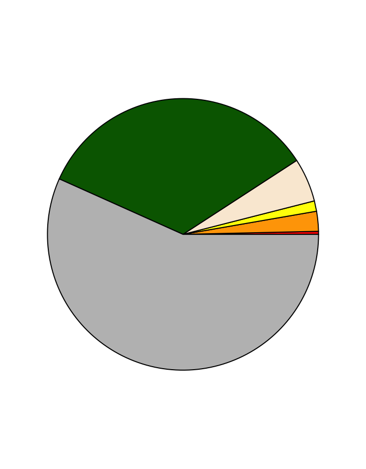

### Los datos:

- El 80% de las plantas dependen de los polinizadores para su reproducción
- El beneficio mundial de los polinizadores para los cultivos se estima en 153 billiones de EUR anuales.
- Los principales polinizadores en España son abejas, dipteros, escarabajos y lepidopteros.
- Tan solo en España hay más de 1.000 species de abejas (el doble que de pajaros).
- La mayoria de abejas viven solitarias y no producen miel.

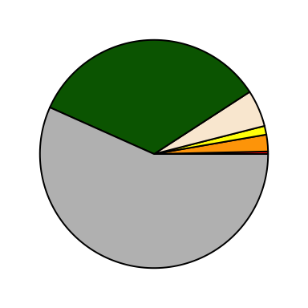

Porcentage abejas amenazadas en Europa. Rojo (críticamente amenazadas) a verde (poco preocupantes). Gris (datos deficientes)- Datos: [IUCN](https://www.iucn.org/content/european-red-list-bees)

# La crisis de los polinizadores

### El Problema

Las causas del declive de muchas especies de polinizadores son variadas. La primera es **la pérdida de hábitat**. Más del 40% de la superficie terrestre libre de hielo está modificada por el hombre, especialmente para uso agrícola. Muchos polinizadores no pueden prosperar en estos ambientes ya que no encuentran alimento o sitios donde nidificar. **El cambio climático** también afecta a los polinizadores, por ejemplo, su periodo de actividad ya ha avanzado unas dos semanas respecto a hace 50 años y el rango de distribución de los abejorros ha disminuído sustancialmente. Las **especies exóticas introducidas por el hombre** también están trayendo consigo nuevos **patógenos**, algunos de ellos responsables de la casi desaparición de una especie de abejorro (*Bombus affinis*) en Estados Unidos. Finalmente, las abejas que pueden usar zonas agrícolas se ven expuestas a **pesticidas**. No es de extrañar que se vean afectadas por ellos, ya que los insecticidas, como los neonicotinoides y otros, están diseñados para matar insectos, pero también también se ven afectadas por los fungicidas, que eliminan su flora bacteriana, y los herbicidas, que reducen sus recursos florales.

### Foto

[figure not shown]

Una abeja solitaria, *Anthidium florentinum*, visitando Lantana (CC)

### Foto

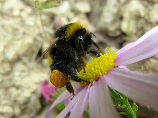

Un abejorro llevando pollen en sis cestas de pollen (corbicula) (CC)

### Foto

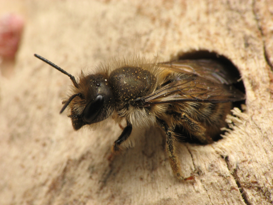

La abeja solitaria *Osmia cornifrons* nidifica en agujeros de la madera. (CC)

### Foto

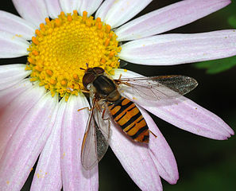

Los sirfidos tambien son buenos polinizadores *Episyrphus balteatus* en una flor (CC)

### Citas

*“A pesar de las amenazas, aun estamos a tiempo de conservar a los polinizadores y el precioso servicio que nos brindan, pero hemos de actuar ya”* (Ignasi Bartomeus, EBD-CSIC)

*“Para mantener una polinización estable necesitamos conservar las especies de polinizadores silvestres”* (Ainhoa Magrach, BC3)

### Recursos

- [Video: Que les pasa a las abejas?](https://www.youtube.com/watch?v=n5udBqq3qYg)
- [Articulo en quercus escrito por el grupo de trabajo ECOFLOR](https://ibartomeus.files.wordpress.com/2015/08/ecoflor_2016-declive-de-las-abejas-quercus.pdf)
- Especial crisis de los polinizadores en la revista Ecosistemas